# Statistical Inference Course Project

Part 2: Basic Inferential Data Analysis

alikaki m

24 October, 2015

## Overview:

## Data set information:

library(datasets) data(“ToothGrowth”)

### Data set description:

The *ToothGrowth* data set investigates the effect of vitamin C on tooth growth in guinea pigs. The data set contains 60 observations on 3 variables: *len* denotes the tooth length, *supp* represents the vitamin C supplement type [absorbic acid (VC) or orange juice (OJ)], and *dose* is the dose in milligrams. Note: I am inferring that “VC” represents absorbic acid as the dataset description is poor at best.

The response is the tooth length and we are interested in exploring whether growth is affected by dose or supplement type or both factors. We achieve this through statistical inference; however, it is of interest to complete an exploratory data analysis first in order to drive our inferential statistics.

We first reshape the data set such that we obtain the average tooth length according to supplement type and dose.

```r
library(reshape2)
mt <- melt(ToothGrowth, id = c("supp", "dose"), measure.vars = c("len"))
aveLen <- dcast(mt, supp + dose ~ variable, mean)
aveLen
```

```
##   supp dose   len
## 1   OJ  0.5 13.23
## 2   OJ  1.0 22.70
## 3   OJ  2.0 26.06
## 4   VC  0.5  7.98
## 5   VC  1.0 16.77
## 6   VC  2.0 26.14
```

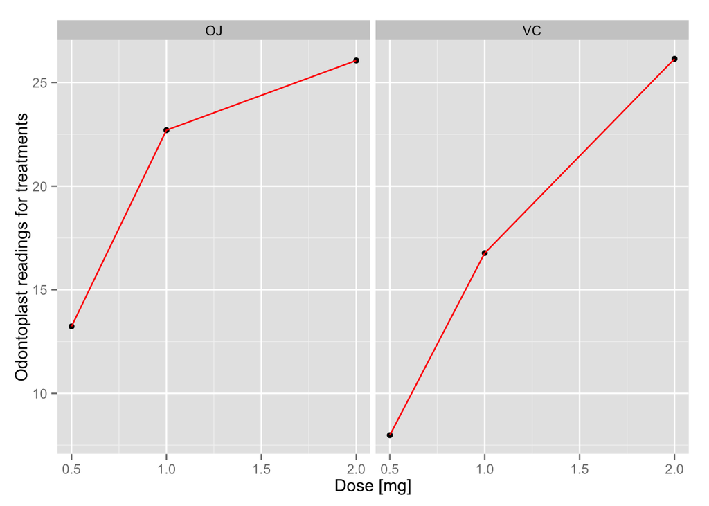

```
## [1] "Figure  1: Relationship between tooth length and supplement dose grouped by supplement."
```

Next, we generate a box plot to compare the distributions between mean tooth length readings obtained from the OJ and VC delivery methods.

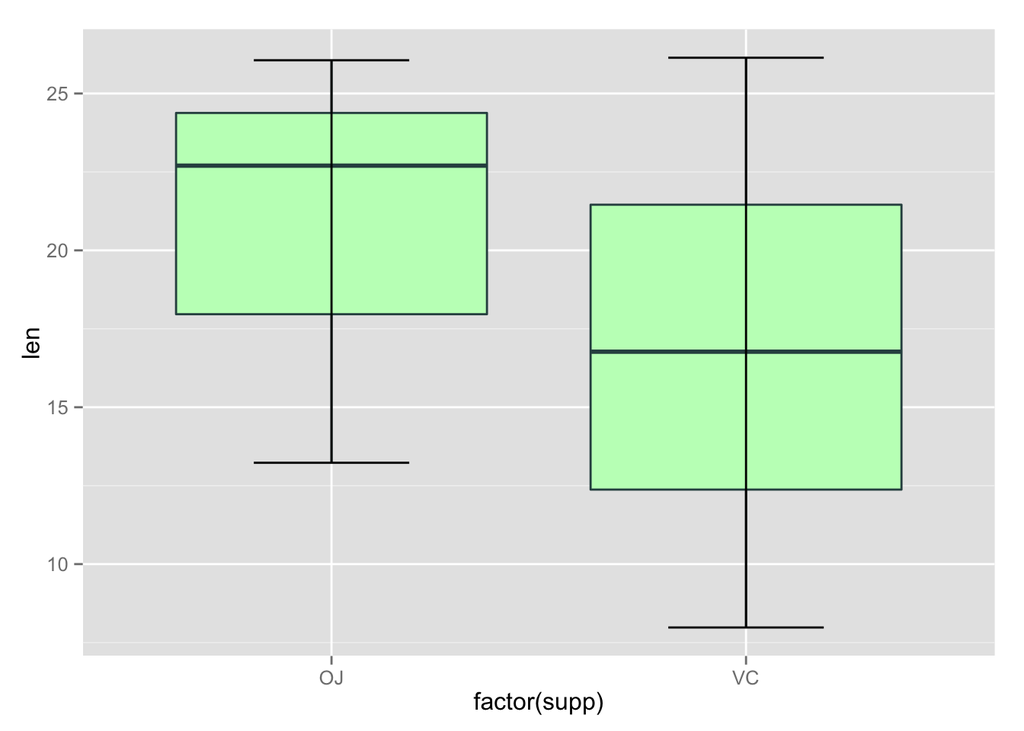

[output not shown]